# hw5

一，实践：《An Introduction to Statistical Learning》Section 5.3 Lab: Cross-validation and the Bootstrap

1，The Validation Set Approach

我们探索了验证集方法的使用，以估计在Auto数据集上拟合各种线性模型所产生的测试错误率。

在开始之前，我们使用set.seed（）函数为R的随机数生成器设置一个种子，以便获得与下面所示完全相同的结果。在执行包含随机性元素的分析（如交叉验证）时，通常设置一个随机种子是一个好主意，这样获得的结果可以在以后的时间精确地再现。

我们首先使用sample（）函数，通过从原始的392个观测值中选择196个观测值的随机子集，将观测值集分成两部分。我们把这些观察值称为训练集。

```r
?sample
```

[output not shown]

[output cut: 78 more lines]

[output not shown]

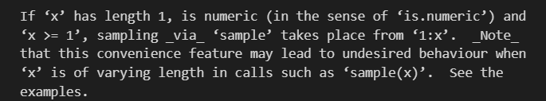

```r
library(ISLR2)
set.seed(1)
train <- sample(392, 196) # 实际上就是从1到392中随机抽取196个数
train
```

1. 324

2. 167

3. 129

4. 299

5. 270

6. 187

7. 307

8. 85

9. 277

10. 362

11. 330

12. 263

13. 329

14. 79

15. 213

16. 37

17. 105

18. 217

19. 366

20. 165

21. 290

22. 383

23. 89

24. 289

25. 340

26. 326

27. 382

28. 42

29. 111

30. 20

31. 44

32. 343

33. 70

34. 121

35. 40

36. 172

37. 25

38. 248

39. 198

40. 39

41. 298

42. 280

43. 160

44. 14

45. 130

46. 45

47. 22

48. 206

49. 230

50. 193

51. 104

52. 367

53. 255

54. 341

55. 342

56. 103

57. 331

58. 13

59. 296

60. 375

61. 176

62. 279

63. 110

64. 84

65. 29

66. 141

67. 252

68. 221

69. 108

70. 304

71. 33

72. 347

73. 149

74. 287

75. 102

76. 145

77. 118

78. 323

79. 107

80. 64

81. 224

82. 337

83. 51

84. 325

85. 372

86. 138

87. 390

88. 389

89. 282

90. 143

91. 285

92. 170

93. 48

94. 204

95. 295

96. 24

97. 181

98. 214

99. 225

100. 163

101. 43

102. 1

103. 328

104. 78

105. 284

106. 116

107. 233

108. 61

109. 86

110. 374

111. 49

112. 242

113. 246

114. 247

115. 239

116. 219

117. 135

118. 364

119. 363

120. 310

121. 53

122. 348

123. 65

124. 376

125. 124

126. 77

127. 218

128. 98

129. 194

130. 19

131. 31

132. 174

133. 237

134. 75

135. 16

136. 358

137. 9

138. 50

139. 92

140. 122

141. 152

142. 386

143. 207

144. 244

145. 229

146. 350

147. 355

148. 391

149. 223

150. 373

151. 309

152. 140

153. 126

154. 349

155. 344

156. 319

157. 258

158. 15

159. 271

160. 388

161. 195

162. 201

163. 318

164. 17

165. 212

166. 127

167. 133

168. 41

169. 384

170. 392

171. 159

172. 117

173. 72

174. 36

175. 315

176. 294

177. 157

178. 378

179. 313

180. 306

181. 272

182. 106

183. 185

184. 88

185. 281

186. 228

187. 238

188. 368

189. 80

190. 30

191. 93

192. 234

193. 220

194. 240

195. 369

196. 164

然后，我们使用lm（）中的subset选项，仅使用与训练集对应的观测值进行线性回归。

```r
dim(Auto) # 392 9
Auto
nrow(Auto) #确实是392行，但是Auto显示数据的时候最末尾的row index是397
```

1. 392

2. 9

A data.frame: 392 × 9

|  | mpg <dbl> | cylinders <int> | displacement <dbl> | horsepower <int> | weight <int> | acceleration <dbl> | year <int> | origin <int> | name <fct> |
| --- | --- | --- | --- | --- | --- | --- | --- | --- | --- |
| 1 | 18 | 8 | 307 | 130 | 3504 | 12.0 | 70 | 1 | chevrolet chevelle malibu |
| 2 | 15 | 8 | 350 | 165 | 3693 | 11.5 | 70 | 1 | buick skylark 320 |
| 3 | 18 | 8 | 318 | 150 | 3436 | 11.0 | 70 | 1 | plymouth satellite |
| 4 | 16 | 8 | 304 | 150 | 3433 | 12.0 | 70 | 1 | amc rebel sst |
| 5 | 17 | 8 | 302 | 140 | 3449 | 10.5 | 70 | 1 | ford torino |
| 6 | 15 | 8 | 429 | 198 | 4341 | 10.0 | 70 | 1 | ford galaxie 500 |
| 7 | 14 | 8 | 454 | 220 | 4354 | 9.0 | 70 | 1 | chevrolet impala |
| 8 | 14 | 8 | 440 | 215 | 4312 | 8.5 | 70 | 1 | plymouth fury iii |
| 9 | 14 | 8 | 455 | 225 | 4425 | 10.0 | 70 | 1 | pontiac catalina |
| 10 | 15 | 8 | 390 | 190 | 3850 | 8.5 | 70 | 1 | amc ambassador dpl |
| 11 | 15 | 8 | 383 | 170 | 3563 | 10.0 | 70 | 1 | dodge challenger se |
| 12 | 14 | 8 | 340 | 160 | 3609 | 8.0 | 70 | 1 | plymouth 'cuda 340 |
| 13 | 15 | 8 | 400 | 150 | 3761 | 9.5 | 70 | 1 | chevrolet monte carlo |
| 14 | 14 | 8 | 455 | 225 | 3086 | 10.0 | 70 | 1 | buick estate wagon (sw) |
| 15 | 24 | 4 | 113 | 95 | 2372 | 15.0 | 70 | 3 | toyota corona mark ii |
| 16 | 22 | 6 | 198 | 95 | 2833 | 15.5 | 70 | 1 | plymouth duster |
| 17 | 18 | 6 | 199 | 97 | 2774 | 15.5 | 70 | 1 | amc hornet |
| 18 | 21 | 6 | 200 | 85 | 2587 | 16.0 | 70 | 1 | ford maverick |
| 19 | 27 | 4 | 97 | 88 | 2130 | 14.5 | 70 | 3 | datsun pl510 |
| 20 | 26 | 4 | 97 | 46 | 1835 | 20.5 | 70 | 2 | volkswagen 1131 deluxe sedan |
| 21 | 25 | 4 | 110 | 87 | 2672 | 17.5 | 70 | 2 | peugeot 504 |
| 22 | 24 | 4 | 107 | 90 | 2430 | 14.5 | 70 | 2 | audi 100 ls |
| 23 | 25 | 4 | 104 | 95 | 2375 | 17.5 | 70 | 2 | saab 99e |
| 24 | 26 | 4 | 121 | 113 | 2234 | 12.5 | 70 | 2 | bmw 2002 |
| 25 | 21 | 6 | 199 | 90 | 2648 | 15.0 | 70 | 1 | amc gremlin |
| 26 | 10 | 8 | 360 | 215 | 4615 | 14.0 | 70 | 1 | ford f250 |
| 27 | 10 | 8 | 307 | 200 | 4376 | 15.0 | 70 | 1 | chevy c20 |
| 28 | 11 | 8 | 318 | 210 | 4382 | 13.5 | 70 | 1 | dodge d200 |
| 29 | 9 | 8 | 304 | 193 | 4732 | 18.5 | 70 | 1 | hi 1200d |
| 30 | 27 | 4 | 97 | 88 | 2130 | 14.5 | 71 | 3 | datsun pl510 |
| ⋮ | ⋮ | ⋮ | ⋮ | ⋮ | ⋮ | ⋮ | ⋮ | ⋮ | ⋮ |
| 368 | 28 | 4 | 112 | 88 | 2605 | 19.6 | 82 | 1 | chevrolet cavalier |
| 369 | 27 | 4 | 112 | 88 | 2640 | 18.6 | 82 | 1 | chevrolet cavalier wagon |
| 370 | 34 | 4 | 112 | 88 | 2395 | 18.0 | 82 | 1 | chevrolet cavalier 2-door |
| 371 | 31 | 4 | 112 | 85 | 2575 | 16.2 | 82 | 1 | pontiac j2000 se hatchback |
| 372 | 29 | 4 | 135 | 84 | 2525 | 16.0 | 82 | 1 | dodge aries se |
| 373 | 27 | 4 | 151 | 90 | 2735 | 18.0 | 82 | 1 | pontiac phoenix |
| 374 | 24 | 4 | 140 | 92 | 2865 | 16.4 | 82 | 1 | ford fairmont futura |
| 375 | 36 | 4 | 105 | 74 | 1980 | 15.3 | 82 | 2 | volkswagen rabbit l |
| 376 | 37 | 4 | 91 | 68 | 2025 | 18.2 | 82 | 3 | mazda glc custom l |
| 377 | 31 | 4 | 91 | 68 | 1970 | 17.6 | 82 | 3 | mazda glc custom |
| 378 | 38 | 4 | 105 | 63 | 2125 | 14.7 | 82 | 1 | plymouth horizon miser |
| 379 | 36 | 4 | 98 | 70 | 2125 | 17.3 | 82 | 1 | mercury lynx l |
| 380 | 36 | 4 | 120 | 88 | 2160 | 14.5 | 82 | 3 | nissan stanza xe |
| 381 | 36 | 4 | 107 | 75 | 2205 | 14.5 | 82 | 3 | honda accord |
| 382 | 34 | 4 | 108 | 70 | 2245 | 16.9 | 82 | 3 | toyota corolla |
| 383 | 38 | 4 | 91 | 67 | 1965 | 15.0 | 82 | 3 | honda civic |
| 384 | 32 | 4 | 91 | 67 | 1965 | 15.7 | 82 | 3 | honda civic (auto) |
| 385 | 38 | 4 | 91 | 67 | 1995 | 16.2 | 82 | 3 | datsun 310 gx |
| 386 | 25 | 6 | 181 | 110 | 2945 | 16.4 | 82 | 1 | buick century limited |
| 387 | 38 | 6 | 262 | 85 | 3015 | 17.0 | 82 | 1 | oldsmobile cutlass ciera (diesel) |
| 388 | 26 | 4 | 156 | 92 | 2585 | 14.5 | 82 | 1 | chrysler lebaron medallion |
| 389 | 22 | 6 | 232 | 112 | 2835 | 14.7 | 82 | 1 | ford granada l |
| 390 | 32 | 4 | 144 | 96 | 2665 | 13.9 | 82 | 3 | toyota celica gt |
| 391 | 36 | 4 | 135 | 84 | 2370 | 13.0 | 82 | 1 | dodge charger 2.2 |
| 392 | 27 | 4 | 151 | 90 | 2950 | 17.3 | 82 | 1 | chevrolet camaro |
| 393 | 27 | 4 | 140 | 86 | 2790 | 15.6 | 82 | 1 | ford mustang gl |
| 394 | 44 | 4 | 97 | 52 | 2130 | 24.6 | 82 | 2 | vw pickup |
| 395 | 32 | 4 | 135 | 84 | 2295 | 11.6 | 82 | 1 | dodge rampage |
| 396 | 28 | 4 | 120 | 79 | 2625 | 18.6 | 82 | 1 | ford ranger |
| 397 | 31 | 4 | 119 | 82 | 2720 | 19.4 | 82 | 1 | chevy s-10 |

392

```r
sum(is.na(Auto))
colSums(is.na(Auto))
Auto[!complete.cases(Auto), ]
```

0

**mpg**

0

**cylinders**

0

**displacement**

0

**horsepower**

0

**weight**

0

**acceleration**

0

**year**

0

**origin**

0

**name**

0

A data.frame: 0 × 9

| mpg | cylinders | displacement | horsepower | weight | acceleration | year | origin | name |
| --- | --- | --- | --- | --- | --- | --- | --- | --- |
| <dbl> | <int> | <dbl> | <int> | <int> | <dbl> | <int> | <int> | <fct> |

```r
lm.fit <- lm(mpg ~ horsepower, data = Auto, subset = train)
```

现在，我们使用predict（）函数来估计所有392个观测值的响应，并使用mean（）函数来计算验证集中196个观测值的MSE。注意，下面的-train索引只选择不在训练集中的观测值。

```r
attach(Auto)

# MSE实际上是一个model的标准，就是最小化残差平方和
mean((mpg - predict(lm.fit, Auto))[-train]^2) # mpg - predict(lm.fit, Auto)是残差，[-train]是去掉train的部分，所以我们只考虑test的部分，然后对这一部分求平方和，再求均值


# 线性回归拟合的估计检验MSE为23.27
```

23.2660086465003

我们可以使用poly（）函数来估计二次回归和三次回归的测试误差。

```r
# 前面拟合的是horsepower的线性模型，现在拟合horsepower的二次模型
lm.fit2 <- lm(mpg ~ poly(horsepower, 2), data = Auto,subset = train)
mean((mpg - predict(lm.fit2, Auto))[-train]^2)
```

18.7164594933828

```r
lm.fit3 <- lm(mpg ~ poly(horsepower, 3), data = Auto,subset = train)
mean((mpg- predict(lm.fit3,Auto))[-train]^2)
```

18.7940067973945

错误率分别为18.72和18.79。如果我们选择一个不同的训练集，那么我们将在验证集上获得一些不同的误差。

```r
set.seed(2)
train <- sample(392, 196) # 和前面的sample(392, 196)不同，这里的train是随机的，因为设置了set.seed(2)，不同的随机种子会得到不同的train
lm.fit <- lm(mpg ~ horsepower, subset = train)
mean((mpg - predict(lm.fit, Auto))[-train]^2)
lm.fit2 <- lm(mpg ~ poly(horsepower, 2), data = Auto,subset = train)
mean((mpg - predict(lm.fit2, Auto))[-train]^2)
lm.fit3 <- lm(mpg ~ poly(horsepower, 3), data = Auto,subset = train)
mean((mpg - predict(lm.fit3, Auto))[-train]^2)

# 通过将观测数据分割成训练集和验证集，我们发现线性、二次和三次项模型的验证集错误率分别为25.73、20.43和20.39。
```

25.7265106448139

20.4303642741463

20.3853268638776

这些结果与我们之前的发现一致：使用马力的二次函数预测mpg的模型比只涉及马力的线性函数的模型表现更好，并且几乎没有证据支持使用马力的三次函数的模型。

2，Leave-One-Out Cross-Validation LOOCV

可以使用glm（）和cv.glm（）函数自动计算任何广义线性模型的LOOCV估计。在第4章的实验中，我们使用glm（）函数通过传递family = "binomial"参数来执行逻辑回归。但是，如果我们使用glm（）来拟合模型而不传递family参数，那么它将执行线性回归，就像lm（）函数一样。举个例子，

```r
?glm
```

[output not shown]

[output cut: 335 more lines]

[output not shown]

```r
glm.fit <- glm(mpg ~ horsepower, data = Auto)
coef(glm.fit)

lm.fit <- lm(mpg ~ horsepower, data = Auto)
coef(lm.fit)
```

**(Intercept)**

39.9358610211705

**horsepower**

-0.157844733353654

**(Intercept)**

39.9358610211705

**horsepower**

-0.157844733353654

```r
?cv.glm
```

[output not shown]

[output cut: 71 more lines]

[output not shown]

```r
library(boot)
glm.fit <- glm(mpg ~ horsepower, data = Auto)
cv.err <- cv.glm(Auto, glm.fit)
cv.err$delta
cv.err
```

1. 24.2315135179292

2. 24.2311440937562

[output not shown]

[output cut: 100 more lines]

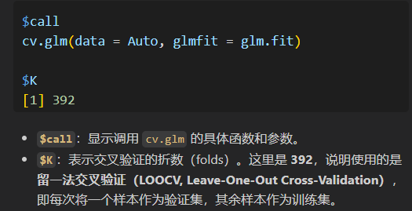

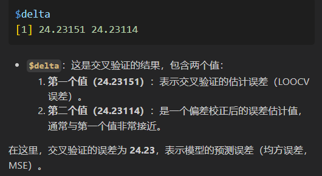

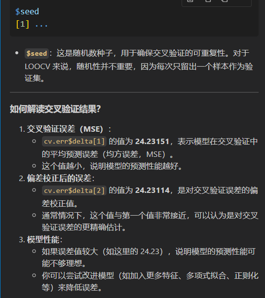

glm（）函数生成一个包含多个组件的列表。delta增量向量中的两个数字包含交叉验证结果。在这种情况下，数字是相同的（最多两个小数点），并对应于（5.1）中给出的LOOCV统计。下面，我们讨论两个数字不同的情况。我们对测试误差的交叉验证估计约为24.23。

对于越来越复杂的多项式拟合，我们可以重复这个过程。为了自动化这个过程，我们使用for（）函数来启动一个for循环，该循环迭代地拟合i = 1到i = 10阶多项式的多项式回归，计算相关的交叉验证误差，并将其存储在向量cv.error的第i个元素中。我们从初始化向量开始。

```r
?rep
```

[output not shown]

[output cut: 93 more lines]

[output not shown]

```r
cv.error <- rep(0, 10) # 初始化一个长度为10的0向量
for (i in 1:10) {
    glm.fit <- glm(mpg ~ poly(horsepower, i), data = Auto)
    cv.error[i] <- cv.glm(Auto, glm.fit)$delta[1]
 }
cv.error
```

1. 24.2315135179292

2. 19.2482131244897

3. 19.3349840640291

4. 19.4244303104302

5. 19.0332138547041

6. 18.9786436582254

7. 18.8330450653182

8. 18.9611507120531

9. 19.0686299814602

10. 19.4909322993291

3，k-Fold Cross-Validation

CV. glm（）函数也可用于实现k-fold CV。下面我们在Auto数据集上使用k = 10，这是k的常见选择。我们再次设置一个随机种子并初始化一个向量，我们将在其中存储对应于一阶到十阶多项式拟合的CV误差。

```r
set.seed(17)
cv.error.10 <- rep(0, 10)
cv.error_adjusted.10 <- rep(0, 10)
for (i in 1:10) {
    glm.fit <- glm(mpg ~ poly(horsepower, i), data = Auto)
    cv.error.10[i] <- cv.glm(Auto, glm.fit, K = 10)$delta[1]
    cv.error_adjusted.10[i] <- cv.glm(Auto, glm.fit, K = 10)$delta[2]
}
cv.error.10
cv.error_adjusted.10
```

1. 24.2720671232254

2. 19.2710460572794

3. 19.2740603574178

4. 19.675384633584

5. 18.8810777855038

6. 19.1180622517383

7. 18.8224924860562

8. 18.7832056509129

9. 18.7933601460066

10. 19.4181382235426

1. 24.0752254085165

2. 19.1343565342066

3. 19.2946059628244

4. 19.477548781933

5. 19.1491078683196

6. 18.9462130938207

7. 18.7437300201072

8. 18.8308225749525

9. 19.0500608092815

10. 18.9629045025418

注意，计算时间比LOOCV短。(原则上，最小二乘线性模型的LOOCV的计算时间应该比k-fold CV快，因为LOOCV的公式（5.2）是可用的；然而，不幸的是，cv.glm（）函数并没有使用这个公式。我们仍然没有看到多少证据表明，使用三次或高阶多项式项比简单使用二次ft项导致更低的测试误差。

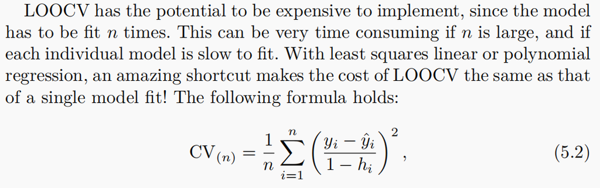

我们在5.3.2节中看到，在执行LOOCV时，与delta相关的两个数字本质上是相同的。当我们执行k倍CV时，与delta相关的两个数字略有不同。第一个是标准的k倍CV估计，如（5.3）所示。第二种是修正了偏见的版本。在这个数据集上，这两个估计非常相似。

确实，我们修改了一下代码，发现结果中出现的1和2是略有区别的

4，The Bootstrap

（1）Estimating the Accuracy of a Statistic of Interest

自举方法的一大优点是它可以应用于几乎所有的情况。不需要复杂的数学计算。在R中执行自举分析只需要两个步骤。首先，我们必须创建一个函数来计算感兴趣的统计信息。其次，我们使用boot（）函数，它是boot库的一部分，通过从具有替换的数据集中重复采样观察值来执行bootstrap。

ISLR2包中的Portfolio数据集是100对收益的模拟数据，以第5.2节中描述的方式生成。为了说明在该数据上使用自举法，我们必须首先创建一个函数alpha.fn()，它将（X， Y）数据以及指示应使用哪些观测值来估计α的向量作为输入。然后，该函数根据所选的观测值输出α的估计。

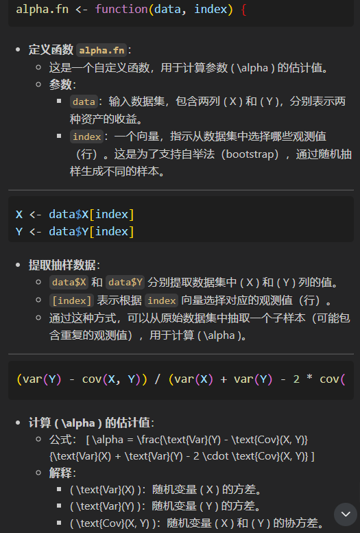

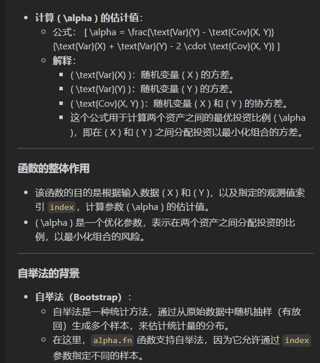

```r
head(Portfolio)
```

A data.frame: 6 × 2

|  | X <dbl> | Y <dbl> |
| --- | --- | --- |
| 1 | -0.8952509 | -0.2349235 |
| 2 | -1.5624543 | -0.8851760 |
| 3 | -0.4170899 | 0.2718880 |
| 4 | 1.0443557 | -0.7341975 |
| 5 | -0.3155684 | 0.8419834 |
| 6 | -1.7371238 | -2.0371910 |

```r
alpha.fn <- function(data, index) {
     X <- data$X[index]
     Y <- data$Y[index]
    (var(Y) - cov(X, Y)) / (var(X) + var(Y) - 2 * cov(X, Y))
 }
```

该函数返回或输出基于将（5.7）应用于由参数index索引的观测值的α估计值。例如，下面的命令告诉R使用所有100个观测值来估计α。

```r
alpha.fn(Portfolio, 1:100)
```

0.57583207459283

下一个命令使用sample（）函数从1到100的范围中随机选择100个观测值，并进行替换。这相当于构造一个新的bootstrap数据集，并基于新数据集重新计算α hat

```r
?sample
```

[output not shown]

[output cut: 78 more lines]

[output not shown]

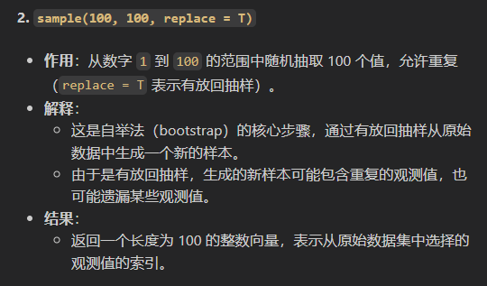

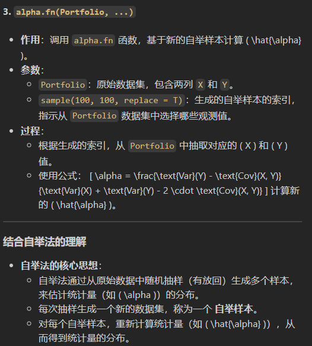

```r
set.seed(7)
alpha.fn(Portfolio, sample(100, 100, replace = T))
```

[output not shown]

我们可以通过多次执行此命令来实现自举分析，记录α的所有相应估计，并计算结果的标准偏差。但是，boot（）函数会自动执行此方法。下面我们对α产生R = 1000的自举估计。

```r
?boot
```

[output not shown]

[output cut: 339 more lines]

[output not shown]

```r
boot(Portfolio , alpha.fn, R = 1000) #  R: The number of bootstrap replicates.
```

```
ORDINARY NONPARAMETRIC BOOTSTRAP


Call:
boot(data = Portfolio, statistic = alpha.fn, R = 1000)


Bootstrap Statistics :
     original      bias    std. error
t1* 0.5758321 0.006171738  0.08939745
```

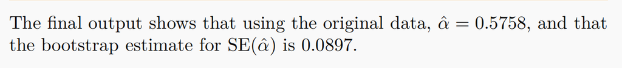

（2）Estimating the Accuracy of a Linear Regression Model

自举方法可用于评估系数估计和预测的可变性，这是一种统计学习方法。在这里，我们使用自举方法来评估β0和β1估计的可变性，β0和β1是线性回归模型的截距和斜率项，该模型使用马力horsepower来预测Auto数据集中的mpg。我们将比较使用自举法获得的估计与使用第3.1.2节中描述的SE（β - 0）和SE（β - 1）公式获得的估计。

我们首先创建一个简单的函数boot.fn()，它接受Auto数据集以及一组观测值的索引，并返回线性回归模型的截距和斜率估计。然后，我们将该函数应用于392个观测值的完整集合，以便使用第3章中常用的线性回归系数估计公式计算整个数据集上β0和β1的估计。注意，我们不需要在函数的开头和结尾使用{和}，因为它只有一行长。

```r
boot.fn <- function(data, index) coef(lm(mpg ~ horsepower, data = data, subset = index))
boot.fn(Auto, 1:392)
```

**(Intercept)**

39.9358610211705

**horsepower**

-0.157844733353654

也可以使用boot.fn（）函数来创建截距和斜率项的自举估计，方法是从具有替换的观测值中随机抽样。这里我们举两个例子。

```r
set.seed(1)
boot.fn(Auto, sample(392, 392, replace = T))
boot.fn(Auto, sample(392, 392, replace = T))
```

**(Intercept)**

40.3404516830189

**horsepower**

-0.163486837689938

**(Intercept)**

40.1186906449022

**horsepower**

-0.157706320543503

接下来，我们使用boot（）函数计算1,000个自举估计的截距和斜率项的标准误差

```r
boot(Auto, boot.fn, 1000)
```

```
ORDINARY NONPARAMETRIC BOOTSTRAP


Call:
boot(data = Auto, statistic = boot.fn, R = 1000)


Bootstrap Statistics :
      original        bias    std. error
t1* 39.9358610  0.0544513229 0.841289790
t2* -0.1578447 -0.0006170901 0.007343073
```

这表明SE（β - 0）的自举估计为0.84，SE（β - 1）的自举估计为0.0073。如3.1.2节所述，可以使用标准公式计算线性模型中回归系数的标准误差。这些可以使用summary（）函数获得。

```r
summary(lm(mpg ~ horsepower, data = Auto))$coef
```

A matrix: 2 × 4 of type dbl

|  | Estimate | Std. Error | t value | Pr(>\|t\|) |
| --- | --- | --- | --- | --- |
| (Intercept) | 39.9358610 | 0.717498656 | 55.65984 | 1.220362e-187 |
| horsepower | -0.1578447 | 0.006445501 | -24.48914 | 7.031989e-81 |

使用第3.1.2节的公式获得的β - 0和β - 1的标准误差估计为截距0.717，斜率0.0064。有趣的是，这些估计值与使用自举法获得的估计值有些不同。这是否表明引导系统有问题？事实上，它暗示的恰恰相反。回想一下，第66页的公式3.8中给出的标准公式依赖于某些假设。例如，它们依赖于未知参数σ2，即噪声方差。然后我们使用RSS估计σ2。现在，虽然标准误差的公式不依赖于线性模型的正确性，但σ2的估计是正确的。我们在第92页的图3.8中看到，数据中存在非线性关系，因此线性ft的残差将被夸大，σ²也将被夸大。其次，标准公式假设（有点不切实际）xi是固定的，所有的可变性都来自于误差i的变化。自举方法不依赖于任何这些假设，因此它可能比summary（）函数更准确地估计β´0和β´1的标准误差。

下面我们计算自举标准误差估计和标准线性回归估计，这些估计是由将二次模型拟合到数据中得到的。由于该模型可以很好地描述数据（图3.8），现在，自举估计与SE（β δ 0）、SE（β δ 1）和SE（β δ 2）的标准估计之间有了更好的对应关系。

```r
boot.fn <- function(data, index)
 coef(
lm(mpg ~ horsepower + I(horsepower^2),
data = data, subset = index)
)
set.seed(1)
boot(Auto, boot.fn, 1000)
summary(
lm(mpg ~ horsepower + I(horsepower^2), data = Auto)
)$coef
```

```
ORDINARY NONPARAMETRIC BOOTSTRAP


Call:
boot(data = Auto, statistic = boot.fn, R = 1000)


Bootstrap Statistics :
        original        bias     std. error
t1* 56.900099702  3.511640e-02 2.0300222526
t2* -0.466189630 -7.080834e-04 0.0324241984
t3*  0.001230536  2.840324e-06 0.0001172164
```

A matrix: 3 × 4 of type dbl

|  | Estimate | Std. Error | t value | Pr(>\|t\|) |
| --- | --- | --- | --- | --- |
| (Intercept) | 56.900099702 | 1.8004268063 | 31.60367 | 1.740911e-109 |
| horsepower | -0.466189630 | 0.0311246171 | -14.97816 | 2.289429e-40 |
| I(horsepower^2) | 0.001230536 | 0.0001220759 | 10.08009 | 2.196340e-21 |

二，Section 5.4 Exercises 2, 5, 6, 7

2，

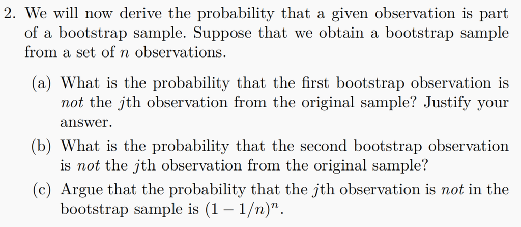

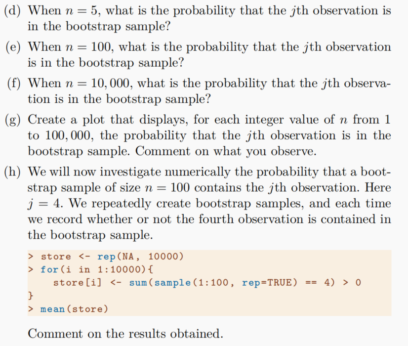

a,

是第j个的先验概率为p，则此处1 - p = $1 - 1/n$.

b， 因为bootstrap是随机、暂且认为是有放回的抽样，则p = $1 - 1/n$

c，

假设bootstrap是随机的、有放回的抽样，且每次抽样之间相互独立，则一次抽样抽不到第j个obs的概率是p = $1 - 1/n$，依据乘法原理，重复n次即可；

从抽样的角度来看，其实就是为了使第j个观测值不在样本中，它必须在$n$个位置中都不被选中

d， 依据c，该事件的补集是第j个obs在bootstrap中，代码如下：

```r
calc_p <- function(n){

    return(1-(1-1/n)**n)
}
calc_p(5)
```

0.67232

```r
# e，同样可以带入函数，n=100
calc_p(100)
```

0.633967658726771

```r
# f
calc_p(1000)
```

0.632304575229036

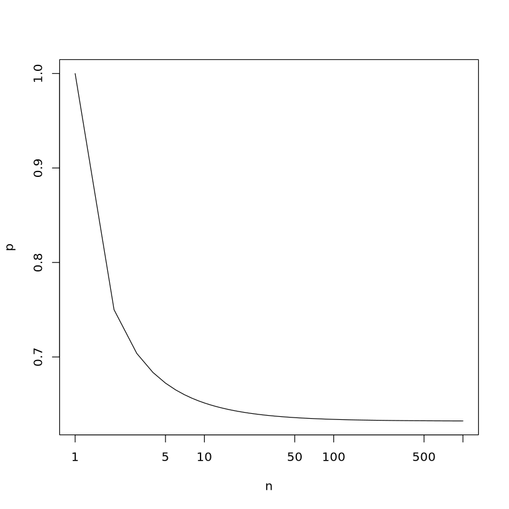

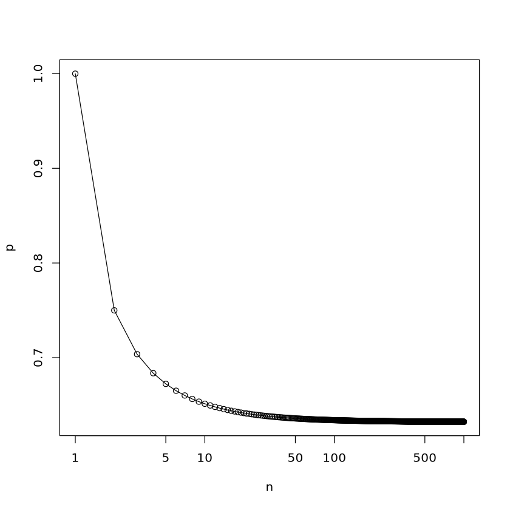

```r
# g

calc_plot <- function(n){
    x <- 1:n
    plot(x,calc_p(x),log = "x",type = "l",xlab = "n",ylab = "p")
}
calc_plot(1000)

calc_plot_v2 <- function(n){
    x <- 1:n
    plot(x,calc_p(x),log = "x",type = "o",xlab = "n",ylab = "p")
}
calc_plot_v2(1000)

# 抽样概率值随着抽样数目的增加，不断减小，但是趋向于一个稳定值，这个稳定值是1-1/e（可以由幂指函数的极限推导出来）
```

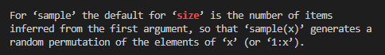

sample中如果不指定size参数的话，则抽样的数目就是输入x的dim

```r
# h
# 相当于我只有100个样本，但那是我只想抽到第4个，所以我一直重复抽样这个过程，每次抽样100个，重复10000次，看看有多少次抽到了第4个（至于每次抽到第4个的概率是多少，该函数中是不关注的）
store <- rep(NA, 10000)
for(i in 1:10000){
store[i] <- sum(sample(1:100, rep=TRUE) == 4) > 0
}
mean(store)
```

0.6385

```r
?replicate
```

[output not shown]

[output cut: 156 more lines]

[output not shown]

```r
# sample(x,size,replace ) 实际上就是从数据x中抽size个样，replace=T表示有放回抽样，replace=F表示无放回抽样
# 但是上面只是1次抽样的执行
# 具体的重复抽样，或者说是循环过程，实际上是使用了for循环进行执行，即上面程序中的for i in 1:10000
# 除了使用for循环之外，还可以使用replicate函数进行循环或者重复操作

# ?replicate
# 如果使用replicate函数的话,replicate(n, expr, simplify = "array")
mean(replicate(10000, sum(sample(1:100, rep=TRUE) == 4) > 0))
# 0.6398，和前面使用for循环得到的值0.6385差不多，实际上如果抽样次数增加的话，那么最后获得的概率值是会收敛到一起的
```

0.6398

我们可以发现，当在数字1：100中重采样时，采样样本中包括第4个obs的概率接近于前面的题目e，也就是接近于第4个观测包含在样本中的概率值$1 - (1 - 1/100)^{100}$.

其实本质上就是说通过枚举法也就是bootstrap获取的某个事件的概率估计是和通过概率计算一致的

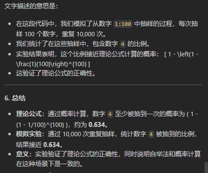

```r
sample(1:100, rep=TRUE) # 可以发现确实是抽样100个，也就是x的dim
(sample(1:100, rep=TRUE) == 4) # 一个逻辑向量，只有抽到第4个的时候为TRUE
sum(sample(1:100, rep=TRUE) == 4) # 有多少次抽到了第4个，也就是每次抽样中有多少次抽样抽到了第4个
sum(sample(1:100, rep=TRUE) == 4) > 0 # 实际上返回的是1个逻辑值，TRUE或者FALSE，也就是每次抽样中是否抽到了第4个，因为是和没有抽到的次数0作比较
# 综上这个store[i]就是每次抽样中是否抽到了第4个（但是不考虑每次抽样中到底抽到了第4个样本多少次），然后求平均值就是抽到第4个的概率
```

1. 7

2. 31

3. 60

4. 59

5. 20

6. 77

7. 89

8. 47

9. 8

10. 37

11. 7

12. 85

13. 70

14. 15

15. 79

16. 95

17. 37

18. 47

19. 87

20. 72

21. 28

22. 64

23. 32

24. 58

25. 79

26. 48

27. 15

28. 60

29. 35

30. 10

31. 34

32. 56

33. 88

34. 84

35. 6

36. 40

37. 79

38. 78

39. 86

40. 98

41. 77

42. 57

43. 96

44. 99

45. 2

46. 72

47. 27

48. 3

49. 63

50. 3

51. 87

52. 93

53. 78

54. 71

55. 23

56. 21

57. 92

58. 78

59. 17

60. 90

61. 27

62. 75

63. 38

64. 4

65. 15

66. 38

67. 10

68. 90

69. 78

70. 17

71. 98

72. 79

73. 98

74. 98

75. 84

76. 69

77. 97

78. 3

79. 19

80. 47

81. 97

82. 25

83. 10

84. 71

85. 33

86. 98

87. 10

88. 28

89. 10

90. 22

91. 68

92. 35

93. 60

94. 19

95. 78

96. 10

97. 9

98. 81

99. 9

100. 74

1. FALSE

2. FALSE

3. FALSE

4. FALSE

5. FALSE

6. FALSE

7. FALSE

8. FALSE

9. FALSE

10. FALSE

11. FALSE

12. FALSE

13. FALSE

14. FALSE

15. FALSE

16. FALSE

17. FALSE

18. FALSE

19. FALSE

20. FALSE

21. FALSE

22. FALSE

23. FALSE

24. FALSE

25. FALSE

26. FALSE

27. FALSE

28. FALSE

29. FALSE

30. FALSE

31. FALSE

32. FALSE

33. FALSE

34. FALSE

35. FALSE

36. FALSE

37. FALSE

38. FALSE

39. FALSE

40. FALSE

41. FALSE

42. FALSE

43. TRUE

44. FALSE

45. FALSE

46. FALSE

47. FALSE

48. FALSE

49. FALSE

50. FALSE

51. FALSE

52. FALSE

53. FALSE

54. FALSE

55. FALSE

56. FALSE

57. FALSE

58. FALSE

59. FALSE

60. FALSE

61. FALSE

62. FALSE

63. FALSE

64. FALSE

65. FALSE

66. FALSE

67. FALSE

68. FALSE

69. FALSE

70. FALSE

71. FALSE

72. FALSE

73. FALSE

74. FALSE

75. FALSE

76. FALSE

77. FALSE

78. FALSE

79. FALSE

80. FALSE

81. FALSE

82. FALSE

83. FALSE

84. FALSE

85. FALSE

86. FALSE

87. FALSE

88. FALSE

89. FALSE

90. FALSE

91. FALSE

92. FALSE

93. FALSE

94. FALSE

95. FALSE

96. FALSE

97. FALSE

98. FALSE

99. FALSE

100. TRUE

0

FALSE

```r
?sample
```

[output not shown]

[output cut: 78 more lines]

[output not shown]

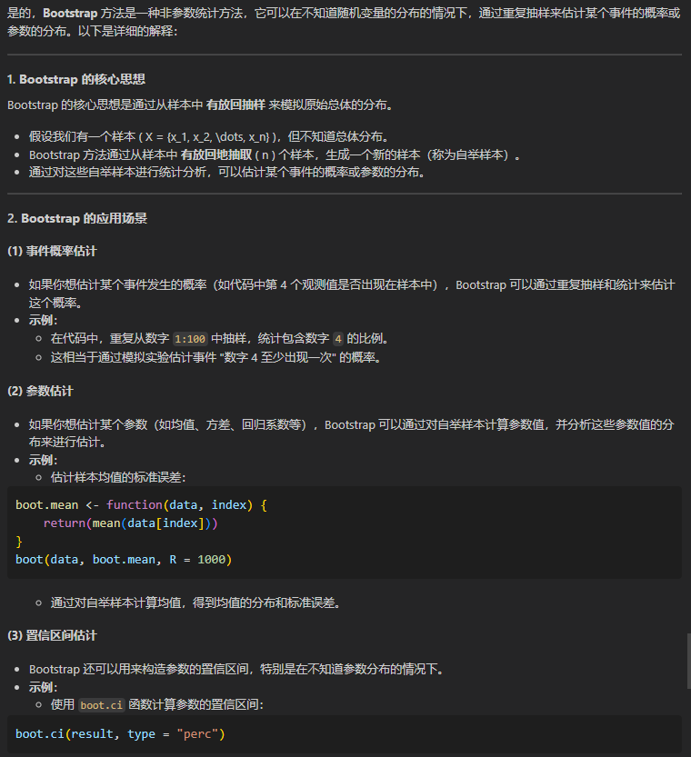

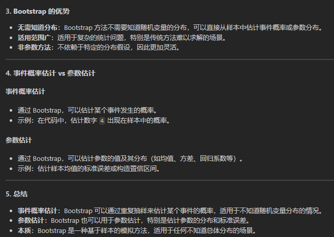

5，

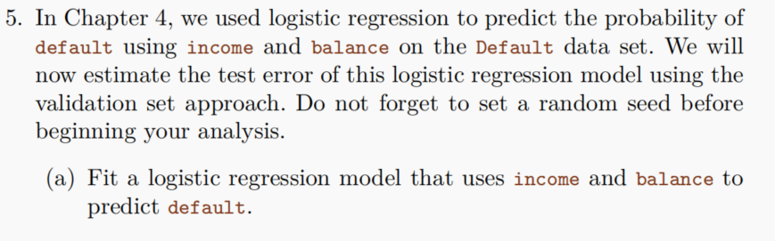

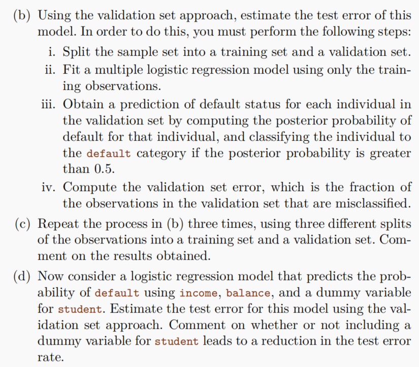

```r
library(ISLR2)
attach(Default)
head(Default)
dim(Default)
```

A data.frame: 6 × 4

|  | default <fct> | student <fct> | balance <dbl> | income <dbl> |
| --- | --- | --- | --- | --- |
| 1 | No | No | 729.5265 | 44361.625 |
| 2 | No | Yes | 817.1804 | 12106.135 |
| 3 | No | No | 1073.5492 | 31767.139 |
| 4 | No | No | 529.2506 | 35704.494 |
| 5 | No | No | 785.6559 | 38463.496 |
| 6 | No | Yes | 919.5885 | 7491.559 |

1. 10000

2. 4

```r
# a

set.seed(2025)

# 使用逻辑回归模型进行拟合
glm.fit <- glm(default ~ income+balance,data=Default,family=binomial)
```

```r
Default
nrow(Default)
```

A data.frame: 10000 × 4

| default <fct> | student <fct> | balance <dbl> | income <dbl> |
| --- | --- | --- | --- |
| No | No | 729.5265 | 44361.625 |
| No | Yes | 817.1804 | 12106.135 |
| No | No | 1073.5492 | 31767.139 |
| No | No | 529.2506 | 35704.494 |
| No | No | 785.6559 | 38463.496 |
| No | Yes | 919.5885 | 7491.559 |
| No | No | 825.5133 | 24905.227 |
| No | Yes | 808.6675 | 17600.451 |
| No | No | 1161.0579 | 37468.529 |
| No | No | 0.0000 | 29275.268 |
| No | Yes | 0.0000 | 21871.073 |
| No | Yes | 1220.5838 | 13268.562 |
| No | No | 237.0451 | 28251.695 |
| No | No | 606.7423 | 44994.556 |
| No | No | 1112.9684 | 23810.174 |
| No | No | 286.2326 | 45042.413 |
| No | No | 0.0000 | 50265.312 |
| No | Yes | 527.5402 | 17636.540 |
| No | No | 485.9369 | 61566.106 |
| No | No | 1095.0727 | 26464.631 |
| No | No | 228.9525 | 50500.182 |
| No | No | 954.2618 | 32457.509 |
| No | No | 1055.9566 | 51317.883 |
| No | No | 641.9844 | 30466.103 |
| No | No | 773.2117 | 34353.314 |
| No | No | 855.0085 | 25211.332 |
| No | No | 642.9997 | 41473.512 |
| No | No | 1454.8633 | 32189.095 |
| No | No | 615.7043 | 39376.395 |
| No | Yes | 1119.5694 | 16556.070 |
| ⋮ | ⋮ | ⋮ | ⋮ |
| No | Yes | 1294.5004 | 25687.33 |
| No | Yes | 180.6201 | 20975.56 |
| No | No | 755.4328 | 14455.87 |
| No | No | 876.1190 | 37668.37 |
| No | Yes | 933.3320 | 26051.40 |
| No | No | 908.3159 | 21287.94 |
| No | No | 218.4176 | 25401.13 |
| No | Yes | 915.4398 | 16624.34 |
| Yes | No | 2202.4624 | 47287.26 |
| No | No | 173.2492 | 30697.25 |
| No | Yes | 770.0157 | 13684.79 |
| No | No | 739.4180 | 40656.95 |
| No | No | 623.5261 | 59441.31 |
| No | No | 506.6255 | 49861.00 |
| No | No | 875.2416 | 52861.74 |
| No | No | 842.9494 | 39957.13 |
| No | Yes | 401.3327 | 15332.02 |
| No | No | 1092.9066 | 45479.47 |
| No | No | 0.0000 | 41740.69 |
| No | Yes | 999.2811 | 20013.35 |
| No | No | 372.3792 | 25374.90 |
| No | No | 658.7996 | 54802.08 |
| No | No | 1111.6473 | 45490.68 |
| No | No | 938.8362 | 56633.45 |
| No | Yes | 172.4130 | 14955.94 |
| No | No | 711.5550 | 52992.38 |
| No | No | 757.9629 | 19660.72 |
| No | No | 845.4120 | 58636.16 |
| No | No | 1569.0091 | 36669.11 |
| No | Yes | 200.9222 | 16862.95 |

10000

```r
# b

train <- sample(nrow(Default), nrow(Default) / 2) # 10000个样本，随机抽取5000个样本作为训练集
fit <- glm(default ~ income + balance, data = Default, family = "binomial", subset = train)
pred <- ifelse(predict(fit, newdata = Default[-train, ], type = "response") > 0.5, "Yes", "No")
table(pred, Default$default[-train])
mean(pred != Default$default[-train]) # 错分率，因为我们此处是计算test error部分
```

```
pred    No  Yes
  No  4802  114
  Yes   25   59
```

0.0278

```r
(25+114)/(4802+59+25+114) # 错分率，因为我们此处是计算test error部分
```

0.0278

```r
# c

# 同样，划分训练集和测试集，然后计算test error；此时划分3次，计算3次test error，抽3次样
# replicate(n = ,expr = ) 重复执行expr n次
set.seed(2025)

replicate(3, {
  train <- sample(nrow(Default), nrow(Default) / 2)
  fit <- glm(default ~ income + balance, data = Default, family = "binomial", subset = train)
  pred <- ifelse(predict(fit, newdata = Default[-train, ], type = "response") > 0.5, "Yes", "No")
  mean(pred != Default$default[-train])
})
```

1. 0.0278

2. 0.0274

3. 0.0276

得到的结果是可变的，取决于分配到训练和测试的样本。

```r
# d

# glm会自动为factor创建哑变量，所以我们不需要手动创建哑变量

replicate(3, {
  train <- sample(nrow(Default), nrow(Default) / 2)
  fit <- glm(default ~ income + balance + student, data = Default, family = "binomial", subset = train)
  pred <- ifelse(predict(fit, newdata = Default[-train, ], type = "response") > 0.5, "Yes", "No")
  mean(pred != Default$default[-train])
})

# 甚至我们可以重复抽样多次，比如说是10次
replicate(10, {
  train <- sample(nrow(Default), nrow(Default) / 2)
  fit <- glm(default ~ income + balance + student, data = Default, family = "binomial", subset = train)
  pred <- ifelse(predict(fit, newdata = Default[-train, ], type = "response") > 0.5, "Yes", "No")
  mean(pred != Default$default[-train])
})
```

1. 0.0264

2. 0.0278

3. 0.024

1. 0.0266

2. 0.0294

3. 0.0282

4. 0.0252

5. 0.028

6. 0.03

7. 0.0276

8. 0.0262

9. 0.023

10. 0.0284

包括“学生”这一项似乎并没有对测试错误做出实质性的改进。

```r
?glm
```

[output not shown]

[output cut: 335 more lines]

[output not shown]

6，

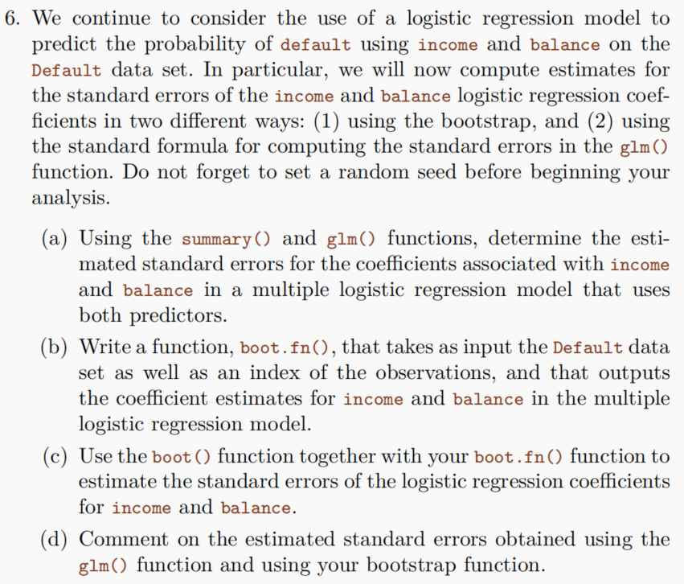

```r
# a

# 系数估计的标注误差SE

fit <- glm(default ~ income + balance, data = Default, family = "binomial")
summary(fit)
```

```
Call:
glm(formula = default ~ income + balance, family = "binomial",
    data = Default)

Coefficients:
              Estimate Std. Error z value Pr(>|z|)
(Intercept) -1.154e+01  4.348e-01 -26.545  < 2e-16 ***
income       2.081e-05  4.985e-06   4.174 2.99e-05 ***
balance      5.647e-03  2.274e-04  24.836  < 2e-16 ***
---
Signif. codes:  0 ‘***’ 0.001 ‘**’ 0.01 ‘*’ 0.05 ‘.’ 0.1 ‘ ’ 1

(Dispersion parameter for binomial family taken to be 1)

    Null deviance: 2920.6  on 9999  degrees of freedom
Residual deviance: 1579.0  on 9997  degrees of freedom
AIC: 1585

Number of Fisher Scoring iterations: 8
```

结果如上

```r
coef(fit)
coef(fit)[-1] # 我们只关心income和balance的系数，去掉截距项也就是去掉第一项
```

**(Intercept)**

-11.5404684366776

**income**

2.08089755005988e-05

**balance**

0.00564710294333903

**income**

2.08089755005988e-05

**balance**

0.00564710294333903

```r
# b

# 系数的估计
boot.fn <- function(x, i) {
  fit <- glm(default ~ income + balance, data = x[i, ], family = "binomial")
  coef(fit)[-1]
}
```

```r
# c

# 1000次bootstrap
library(boot)
set.seed(2025)
boot(Default, boot.fn,  R=1000)
```

```
ORDINARY NONPARAMETRIC BOOTSTRAP


Call:
boot(data = Default, statistic = boot.fn, R = 1000)


Bootstrap Statistics :
        original       bias     std. error
t1* 2.080898e-05 8.657015e-08 4.806336e-06
t2* 5.647103e-03 1.044360e-05 2.282472e-04
```

然后上面运行不是看不到到底传入到i中的是哪些index，或者，我们更关心的是，每次传入的index到底有多少？

我们可以在每次bootstrap前对获取的index即i的长度做一个估计

```r
boot.fn <- function(x, i) {
  cat("Sample size:", length(i), "\n")  # 打印样本大小
  fit <- glm(default ~ income + balance, data = x[i, ], family = "binomial")
  coef(fit)[-1]
}

library(boot)
set.seed(2025)
boot(Default, boot.fn,  R=1000)

# 我们可以看到，每次抽样的样本大小是一样的，都是10000，正好是我们的数据集的大小
# 也就是在 boot 函数中，每次重采样的样本量与原始数据集的行数相同。也就是说，每次重采样的样本大小等于原始数据集的大小，但采样是有放回的
```

[output not shown]

[output cut: 946 more lines]

[output not shown]

```
ORDINARY NONPARAMETRIC BOOTSTRAP


Call:
boot(data = Default, statistic = boot.fn, R = 1000)


Bootstrap Statistics :
        original       bias     std. error
t1* 2.080898e-05 8.657015e-08 4.806336e-06
t2* 5.647103e-03 1.044360e-05 2.282472e-04
```

```r
# 当然，上面其实我们编写的boot.fn函数只是计算了一个我们感兴趣的统计量，也就是income和balance的系数，本身只能说是一次重采样，但是并没有执行1000次重采样
# 所以我们可以使用replicate函数，来执行1000次重采样，然后计算income和balance的系数
# 比如说我们不想重采样和原始数据Default一样大的样本，我们可以使用replicate函数，然后在boot.fn函数中使用sample函数来抽样，我们可以在sample函数中指定每次抽样的大小
# 然后使用replicate的次数来指定重复抽样的次数

# 比如说在sample函数中指定抽样为原始数据大小，其实就是上面的boot函数的效果一样
set.seed(2025)
replicate(1000, {
  fit <- glm(default ~ income + balance, data = Default, family = "binomial", subset = sample(nrow(Default), replace = T))
  coef(fit)[-1]
})
```

A matrix: 2 × 1000 of type dbl

| income | 1.752429e-05 | 2.135893e-05 | 2.005879e-05 | 1.612779e-05 | 2.251989e-05 | 0.0000190053 | 1.695999e-05 | 1.680009e-05 | 2.767444e-05 | 2.265476e-05 | ⋯ | 1.847467e-05 | 1.232525e-05 | 1.878522e-05 | 2.016379e-05 | 1.786319e-05 | 2.225321e-05 | 0.0000163709 | 1.953733e-05 | 1.505011e-05 | 2.276641e-05 |
| --- | --- | --- | --- | --- | --- | --- | --- | --- | --- | --- | --- | --- | --- | --- | --- | --- | --- | --- | --- | --- | --- |
| balance | 5.862314e-03 | 5.649264e-03 | 5.833138e-03 | 5.707187e-03 | 5.717232e-03 | 0.0057253431 | 5.555215e-03 | 5.854121e-03 | 6.068143e-03 | 5.720990e-03 | ⋯ | 5.535235e-03 | 5.540193e-03 | 5.946091e-03 | 5.720023e-03 | 5.768570e-03 | 5.705585e-03 | 0.0053741543 | 5.405553e-03 | 5.496137e-03 | 6.009448e-03 |

```r
?apply
```

[output not shown]

[output cut: 67 more lines]

[output not shown]

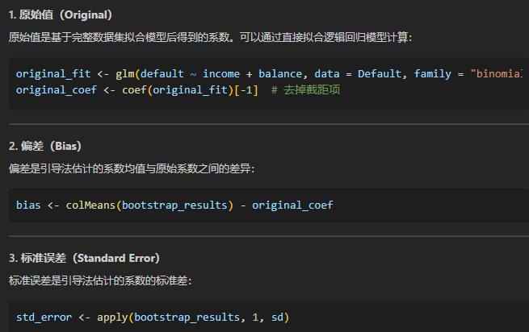

```r
# 如果我们想要不使用boot函数，而是采用自己sample重采样的方式，并计算出相应系数的估计量，我们的代码需要修改
# 要在第二种方法中（使用 replicate）计算类似于第一种方法（boot 函数）的统计量（如原始值、偏差和标准误差），我们需要手动实现这些计算步骤

set.seed(2025)

# 原始值
original_fit <- glm(default ~ income + balance, data = Default, family = "binomial")
original_coef <- coef(original_fit)[-1]  # 去掉截距项

# 1000次重采样
bootstrap_results <- replicate(1000, {
  fit <- glm(default ~ income + balance, data = Default, family = "binomial", subset = sample(nrow(Default), replace = TRUE))
  coef(fit)[-1]  # 返回系数（去掉截距）
})

# 计算统计量
bootstrap_results <- t(bootstrap_results)  # 转置为每行对应一次重采样，比如说前面2x1000的矩阵，就是2个系数，1000次重采样，转置之后就是1000x2
bias <- colMeans(bootstrap_results) - original_coef  # 偏差，该系数每次重采样的均值减去原始系数
# 偏差是指引导法估计的系数均值与原始数据拟合模型得到的系数之间的差异。它反映了引导法估计的系数是否系统性地偏离原始系数
std_error <- apply(bootstrap_results, 2, sd)  # 标准误差,2表示对每列进行计算标准差
# 标准误差是引导法估计的系数的标准差，反映了系数的不确定性或波动性。它表示在多次重采样中，系数的变化范围

# 输出结果
results <- data.frame(
  original = original_coef,
  bias = bias,
  std_error = std_error
)
print(results)
```

```
            original         bias    std_error
income  2.080898e-05 1.146418e-07 4.621740e-06
balance 5.647103e-03 1.058175e-05 2.298475e-04
```

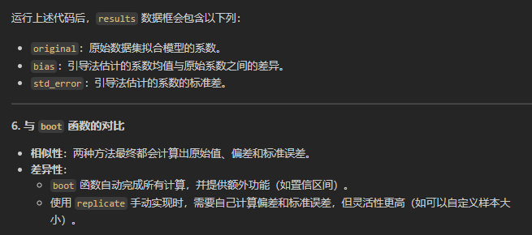

当然，用sample还是用自带的boot返回索引进行重采样，实际上还是有区别的：

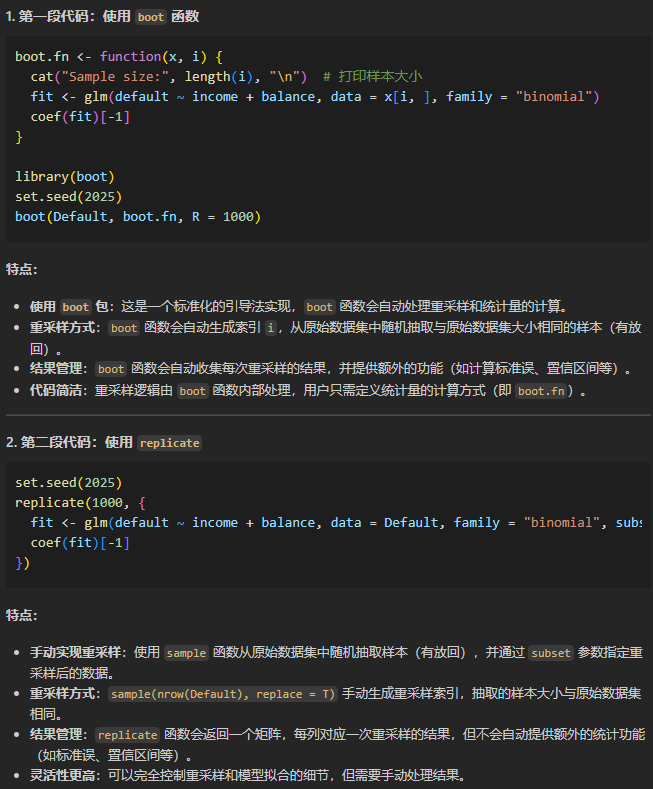

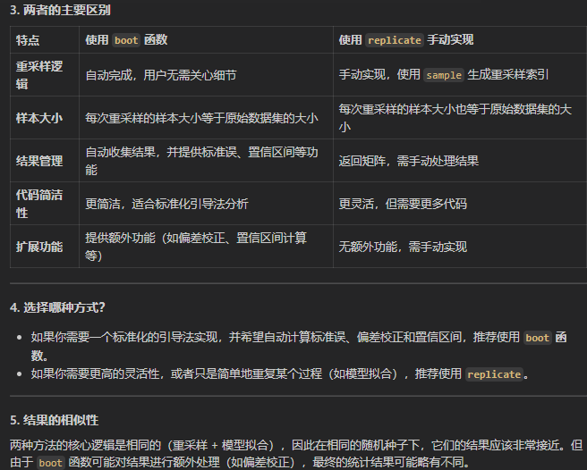

```r
# 如果我们想要自定义每次重采样的数据大小，我们可以在sample函数中指定每次抽样的大小，就比如说上面的代码中的sample(nrow(Default), replace = TRUE)修改一下第1个参数即可
# 前面是在subset参数中指定了抽样的数据，也就是每次抽样的数据都是Default，但是我们也可以自定义每次抽样的数据，比如说我们可以在sample函数中指定每次抽样的大小，然后直接传入到data参数中

boot.fn <- function(x, i) {
  sampled_data <- x[sample(1:nrow(x), size = 100, replace = TRUE), ]  # 自定义样本大小为 100
  fit <- glm(default ~ income + balance, data = sampled_data, family = "binomial")
  coef(fit)[-1]
}
```

下面是对最前面的boot以及boot.fn函数的解释，至于boot.fn的拓展，我们上面已经拓展了挺多的了

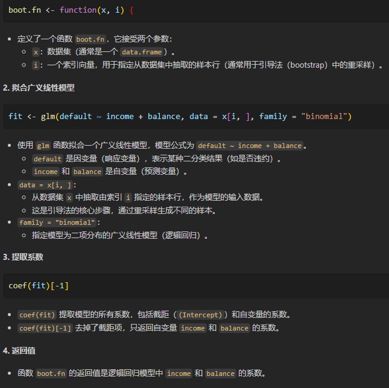

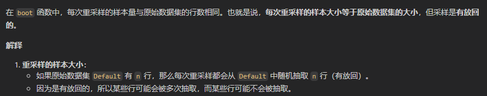

[figure not shown]

```r
?boot
```

[output not shown]

[output cut: 339 more lines]

[output not shown]

d， 总之这一题就是：通过bootstrap获取的标注误差的估计与通过glm标准公式计算的接近

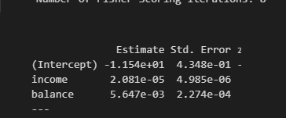

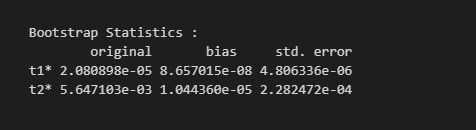

7，

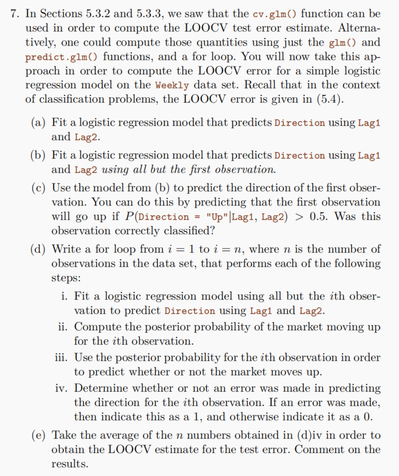

```r
# a
fit <- glm(Direction ~ Lag1 + Lag2, data = Weekly, family = "binomial")
```

```r
# b

fit <- glm(Direction ~ Lag1 + Lag2, data = Weekly[-1, ], family = "binomial")
```

```r
?predict
```

[output not shown]

[output cut: 17 more lines]

[output not shown]

```r
# c

predict(fit, newdata = Weekly[1, , drop = FALSE], type = "response") > 0.5  # 只使用第1行作为测试集，drop = FALSE 保持数据框的维度

# 我们可以发现这个预测的结果是TRUE，也就是预测为Up
```

**1:** TRUE

```r
Weekly[1, ]$Direction

# 我们可以发现实际上是预测错误了，实际上是Down
```

Down

**Levels**:**

1. 'Down'

2. 'Up'

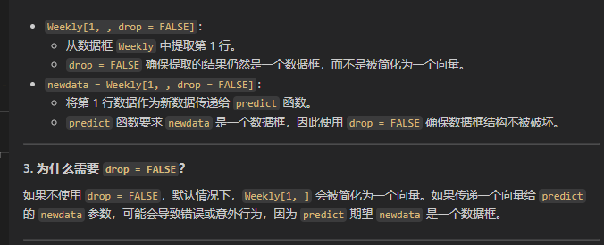

```r
numeric(nrow(Weekly))
?numeric
```

1. 0

2. 0

3. 0

4. 0

5. 0

6. 0

7. 0

8. 0

9. 0

10. 0

11. 0

12. 0

13. 0

14. 0

15. 0

16. 0

17. 0

18. 0

19. 0

20. 0

21. 0

22. 0

23. 0

24. 0

25. 0

26. 0

27. 0

28. 0

29. 0

30. 0

31. 0

32. 0

33. 0

34. 0

35. 0

36. 0

37. 0

38. 0

39. 0

40. 0

41. 0

42. 0

43. 0

44. 0

45. 0

46. 0

47. 0

48. 0

49. 0

50. 0

51. 0

52. 0

53. 0

54. 0

55. 0

56. 0

57. 0

58. 0

59. 0

60. 0

61. 0

62. 0

63. 0

64. 0

65. 0

66. 0

67. 0

68. 0

69. 0

70. 0

71. 0

72. 0

73. 0

74. 0

75. 0

76. 0

77. 0

78. 0

79. 0

80. 0

81. 0

82. 0

83. 0

84. 0

85. 0

86. 0

87. 0

88. 0

89. 0

90. 0

91. 0

92. 0

93. 0

94. 0

95. 0

96. 0

97. 0

98. 0

99. 0

100. 0

101. 0

102. 0

103. 0

104. 0

105. 0

106. 0

107. 0

108. 0

109. 0

110. 0

111. 0

112. 0

113. 0

114. 0

115. 0

116. 0

117. 0

118. 0

119. 0

120. 0

121. 0

122. 0

123. 0

124. 0

125. 0

126. 0

127. 0

128. 0

129. 0

130. 0

131. 0

132. 0

133. 0

134. 0

135. 0

136. 0

137. 0

138. 0

139. 0

140. 0

141. 0

142. 0

143. 0

144. 0

145. 0

146. 0

147. 0

148. 0

149. 0

150. 0

151. 0

152. 0

153. 0

154. 0

155. 0

156. 0

157. 0

158. 0

159. 0

160. 0

161. 0

162. 0

163. 0

164. 0

165. 0

166. 0

167. 0

168. 0

169. 0

170. 0

171. 0

172. 0

173. 0

174. 0

175. 0

176. 0

177. 0

178. 0

179. 0

180. 0

181. 0

182. 0

183. 0

184. 0

185. 0

186. 0

187. 0

188. 0

189. 0

190. 0

191. 0

192. 0

193. 0

194. 0

195. 0

196. 0

197. 0

198. 0

199. 0

200. 0

201. ⋯

202. 0

203. 0

204. 0

205. 0

206. 0

207. 0

208. 0

209. 0

210. 0

211. 0

212. 0

213. 0

214. 0

215. 0

216. 0

217. 0

218. 0

219. 0

220. 0

221. 0

222. 0

223. 0

224. 0

225. 0

226. 0

227. 0

228. 0

229. 0

230. 0

231. 0

232. 0

233. 0

234. 0

235. 0

236. 0

237. 0

238. 0

239. 0

240. 0

241. 0

242. 0

243. 0

244. 0

245. 0

246. 0

247. 0

248. 0

249. 0

250. 0

251. 0

252. 0

253. 0

254. 0

255. 0

256. 0

257. 0

258. 0

259. 0

260. 0

261. 0

262. 0

263. 0

264. 0

265. 0

266. 0

267. 0

268. 0

269. 0

270. 0

271. 0

272. 0

273. 0

274. 0

275. 0

276. 0

277. 0

278. 0

279. 0

280. 0

281. 0

282. 0

283. 0

284. 0

285. 0

286. 0

287. 0

288. 0

289. 0

290. 0

291. 0

292. 0

293. 0

294. 0

295. 0

296. 0

297. 0

298. 0

299. 0

300. 0

301. 0

302. 0

303. 0

304. 0

305. 0

306. 0

307. 0

308. 0

309. 0

310. 0

311. 0

312. 0

313. 0

314. 0

315. 0

316. 0

317. 0

318. 0

319. 0

320. 0

321. 0

322. 0

323. 0

324. 0

325. 0

326. 0

327. 0

328. 0

329. 0

330. 0

331. 0

332. 0

333. 0

334. 0

335. 0

336. 0

337. 0

338. 0

339. 0

340. 0

341. 0

342. 0

343. 0

344. 0

345. 0

346. 0

347. 0

348. 0

349. 0

350. 0

351. 0

352. 0

353. 0

354. 0

355. 0

356. 0

357. 0

358. 0

359. 0

360. 0

361. 0

362. 0

363. 0

364. 0

365. 0

366. 0

367. 0

368. 0

369. 0

370. 0

371. 0

372. 0

373. 0

374. 0

375. 0

376. 0

377. 0

378. 0

379. 0

380. 0

381. 0

382. 0

383. 0

384. 0

385. 0

386. 0

387. 0

388. 0

389. 0

390. 0

391. 0

392. 0

393. 0

394. 0

395. 0

396. 0

397. 0

398. 0

399. 0

400. 0

401. 0

[output not shown]

[output cut: 49 more lines]

[output not shown]

```r
# d

error <- numeric(nrow(Weekly)) # 初始化一个长度为nrow(Weekly)的0向量
for (i in 1:nrow(Weekly)) {
  fit <- glm(Direction ~ Lag1 + Lag2, data = Weekly[-i, ], family = "binomial")
  p <- predict(fit, newdata = Weekly[i, , drop = FALSE], type = "response") > 0.5
  error[i] <- ifelse(p, "Up", "Down") != Weekly$Direction[i]  # 只要预测错误，就是1，否则是0，因为我们要计算test error，而这里是分类的标记，其实就是指示函数indicate function
}
```

```r
error
```

1. 1

2. 1

3. 0

4. 1